# Heart Disease Patient Data Analysis

# 1. Introduction

Heart disease is one of the leading causes of death worldwide, and identifying patterns in patient health data can help in early detection and prevention.

This project analyzes the Heart Disease dataset (originally from the UCI Machine Learning Repository and widely used on Kaggle as the “Heart Disease UCI” dataset) using R programming. The analysis focuses on patient characteristics such as chest pain type, thalassemia test results, cholesterol levels, and heart disease diagnosis outcomes.

The project uses statistical analysis and data visualization to identify important patterns and trends related to heart disease in the dataset.

# 2. Objectives

The main objectives of this project are:

To analyze patient records related to heart disease.  
To study cholesterol level distributions.  
To identify common chest pain types among patients.  
To analyze the distribution of thalassemia test results among patients.  
To examine the relationship between age and maximum heart rate.  
To visualize important patterns using graphs.  
To interpret the results and present meaningful findings.

# 3. Data Importing

```
heart_data <- read.csv("heart_disease_dataset.csv")
head(heart_data)
```

| age | sex | cp | trestbps | chol | fbs | restecg | thalach | exang | oldpeak | slope | ca | thal | target |
| --- | --- | --- | --- | --- | --- | --- | --- | --- | --- | --- | --- | --- | --- |
| 63 | 1 | 1 | 145 | 233 | 1 | 2 | 150 | 0 | 2.3 | 3 | 0 | fixed | 0 |
| 67 | 1 | 4 | 160 | 286 | 0 | 2 | 108 | 1 | 1.5 | 2 | 3 | normal | 1 |
| 67 | 1 | 4 | 120 | 229 | 0 | 2 | 129 | 1 | 2.6 | 2 | 2 | reversible | 0 |
| 37 | 1 | 3 | 130 | 250 | 0 | 0 | 187 | 0 | 3.5 | 3 | 0 | normal | 0 |
| 41 | 0 | 2 | 130 | 204 | 0 | 2 | 172 | 0 | 1.4 | 1 | 0 | normal | 0 |
| 56 | 1 | 2 | 120 | 236 | 0 | 0 | 178 | 0 | 0.8 | 1 | 0 | normal | 0 |

# 4. Understanding the Dataset

```
str(heart_data)
summary(heart_data)
```

The dataset contains **247 patient records** and 14 variables, including demographic information (age, sex), clinical measurements (resting blood pressure, cholesterol, maximum heart rate) and diagnostic test results (chest pain type, thalassemia result, number of major vessels).

# 5. Checking Missing Values

```
colSums(is.na(heart_data))
```

```
age: 0
sex: 0
cp: 0
trestbps: 0
chol: 0
fbs: 0
restecg: 0
thalach: 0
exang: 0
oldpeak: 0
slope: 0
ca: 0
thal: 0
target: 0
```

# 6. Data Cleaning

The dataset uses numeric codes for some categorical variables. These are converted into readable labels to make the analysis and charts easier to interpret (e.g. chest pain type codes 1–4 become "Typical Angina", "Atypical Angina", "Non-Anginal Pain" and "Asymptomatic"; the target variable 0/1 becomes "No Disease" / "Disease Present").

> The dataset contains no missing values, so no rows needed to be removed during cleaning.

# 7. Cholesterol Analysis

> Cholesterol statistics are calculated using the cholesterol level (mg/dl) reported for each patient.

```
mean(heart_data$chol, na.rm = TRUE)
```

```
[1] 247.39
```

```
median(heart_data$chol, na.rm = TRUE)
```

```
[1] 243.0
```

```
var(heart_data$chol, na.rm = TRUE)
```

```
[1] 2593.79
```

```
sd(heart_data$chol, na.rm = TRUE)
```

```
[1] 50.93
```

# Interpretation

The mean represents the average cholesterol level across all patients in the dataset, while the median represents the middle cholesterol value. The difference between the mean and median indicates that the cholesterol distribution is affected by a few unusually high observations.

# 8. Chest Pain Type Analysis

```
cp_count <- table(heart_data$cp_label)
sort(cp_count, decreasing = TRUE)
```

| cp_label | Count |
| --- | --- |
| Asymptomatic | 116 |
| Non-Anginal Pain | 68 |
| Atypical Angina | 44 |
| Typical Angina | 19 |

# 9. Chest Pain Type Visualization

```
barplot(
  sort(cp_count, decreasing = TRUE),
  main = "Chest Pain Type Frequency",
  xlab = "Chest Pain Type",
  ylab = "Number of Patients",
  las = 2
)
```

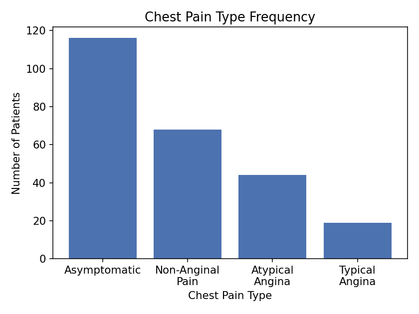

# Interpretation

The bar chart shows the number of patients reporting each chest pain type. Asymptomatic chest pain is the most frequently recorded type in the dataset (116 patients), followed by non-anginal pain (68), atypical angina (44) and typical angina (19). This helps identify which chest pain presentations are most common among the patients in this dataset.

# 10. Thalassemia Test Result Analysis

```
thal_count <- table(heart_data$thal)
thal_count
```

| thal | Count |
| --- | --- |
| normal | 142 |
| reversible | 88 |
| fixed | 17 |

```
barplot(
  thal_count,
  main = "Thalassemia Test Result Distribution",
  xlab = "Thalassemia Result",
  ylab = "Number of Patients",
  las = 2
)
```

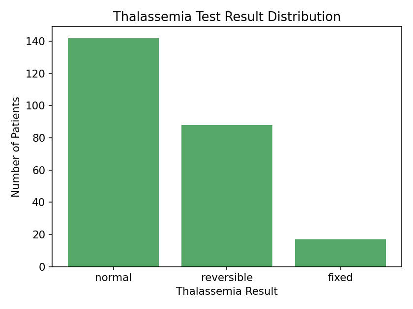

# Interpretation

The bar chart shows the distribution of thalassemia test results across the patients in the dataset. A "normal" result is the most common outcome (142 patients), followed by "reversible" (88) and "fixed" (17) defects. This shows that most patients in the dataset returned a normal thalassemia test result.

# 11. Heart Disease Diagnosis Analysis

```
target_count <- table(heart_data$target_label)
target_count
```

| target_label | Count |
| --- | --- |
| No Disease | 181 |
| Disease Present | 66 |

```
pie(
  target_count,
  main = "Heart Disease Presence vs Absence",
  labels = paste(names(target_count), target_count)
)
```

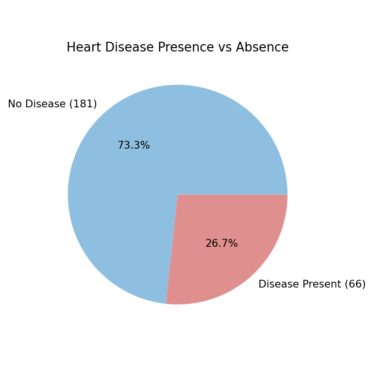

# Interpretation

The pie chart compares patients diagnosed with heart disease against those without it. Out of 247 total patient records, 66 are identified as having heart disease, while 181 are classified as not having the condition. Therefore, patients without heart disease form the larger portion of this dataset.

# 12. Cholesterol Distribution

```
hist(
  heart_data$chol,
  main = "Cholesterol Level Distribution",
  xlab = "Cholesterol (mg/dl)",
  ylab = "Frequency"
)
```

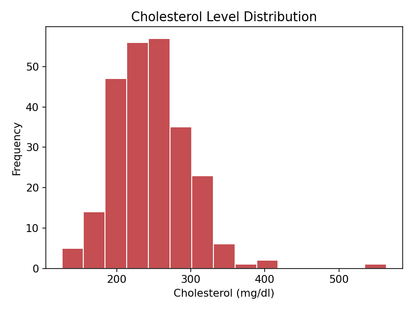

# Interpretation

The histogram shows the distribution of cholesterol levels reported for the patients. Most observations are concentrated in a moderate cholesterol range, while a small number of patients have considerably higher cholesterol values. This indicates that the cholesterol distribution is right-skewed and contains some high-value observations.

# 13. Age vs Maximum Heart Rate Analysis

```
plot(
  heart_data$age,
  heart_data$thalach,
  main = "Age vs Maximum Heart Rate Achieved",
  xlab = "Age",
  ylab = "Maximum Heart Rate (thalach)",
  pch = 19
)
```

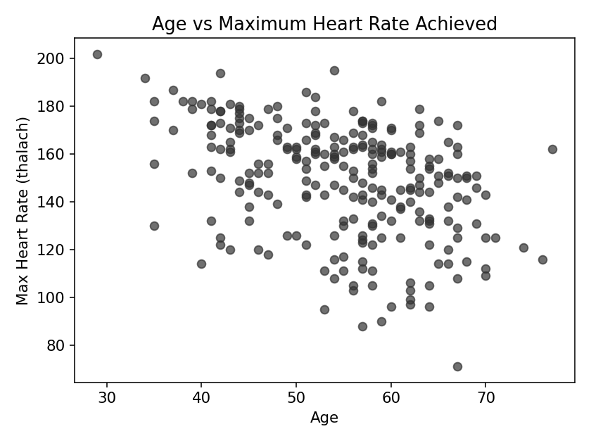

# Interpretation

The scatter plot shows the relationship between a patient's age and the maximum heart rate achieved during testing. The points show a general downward pattern, indicating that older patients tend to achieve a lower maximum heart rate than younger patients.

# 14. Correlation Analysis

```
cor(
  heart_data$age,
  heart_data$thalach,
  use = "complete.obs"
)
```

```
[1] -0.41
```

# Interpretation

The correlation coefficient between age and maximum heart rate is approximately -0.41. This indicates a moderate negative relationship between the two variables. This means that as a patient's age increases, their maximum heart rate tends to decrease. However, correlation does not imply causation.

# 15. Findings

Based on the analysis of the Heart Disease dataset, the following findings were obtained:

1) The dataset contains 247 patient records with no missing values across any of the 14 variables.

2) Asymptomatic chest pain is the most frequently reported chest pain type among patients, followed by non-anginal pain, atypical angina and typical angina.

3) A "normal" thalassemia test result is the most common outcome among patients, followed by "reversible" and "fixed" defects.

4) 66 out of 247 patients are diagnosed with heart disease, while 181 are not.

5) The cholesterol distribution shows that most patients have moderate cholesterol levels (mean 247.39 mg/dl, median 243.0 mg/dl), with a small number of unusually high observations.

6) The correlation coefficient between age and maximum heart rate is approximately -0.41, indicating a moderate negative relationship between the two variables.

7) The visualizations provide useful insights into chest pain types, thalassemia results and cholesterol patterns among heart disease patients.

# 16. Conclusion

This project analyzed a real-world Heart Disease dataset using R programming.

The analysis included data importing, data exploration, missing-value analysis, data cleaning, statistical analysis and data visualization.

The study examined chest pain types, thalassemia test results, cholesterol levels and the relationship between age and maximum heart rate among patients. It also compared the presence and absence of heart disease across the dataset.

The correlation analysis showed a moderate negative relationship between age and maximum heart rate, with a correlation coefficient of approximately -0.41.

Overall, this project demonstrates how R can be used to analyze real-world health data and convert it into meaningful statistical insights and visualization.

# 17. References

Heart Disease Dataset (UCI Machine Learning Repository / Kaggle)  
R Programming Documentation  
R Markdown Documentation